# GET00203 - Estatística Computacional 1

Aula 05 - Distribuições Amostrais - Parte II

[Rafael Erbisti](https://sites.google.com/site/rerbisti)

## Distribuição Amostral da Proporção

O **Teorema do Limite Central** afirma que, para uma população com proporção $p$ de sucessos, a distribuição da proporção amostral $\hat{p}$, para um tamanho de amostra $n$, se aproxima de uma distribuição normal com média $p$ e desvio padrão dado por:

$$\hat{p} \dot{\sim} N\left(p, \sqrt{\frac{p(1 - p)}{n}}\right)$$

#### Fórmulas Teóricas

- **Média da Proporção Amostral**:

  $$\mu_{\hat{p}} = p$$
- **Desvio Padrão (Erro Padrão) da Proporção Amostral**:

  $$\sigma_{\hat{p}} = \sqrt{\frac{p(1 - p)}{n}}$$

Suponha que temos uma população onde a proporção de sucesso é $p=0.5$ (moeda justa). O interesse é ver como a proporção de sucessos varia em amostras de diferentes tamanhos.

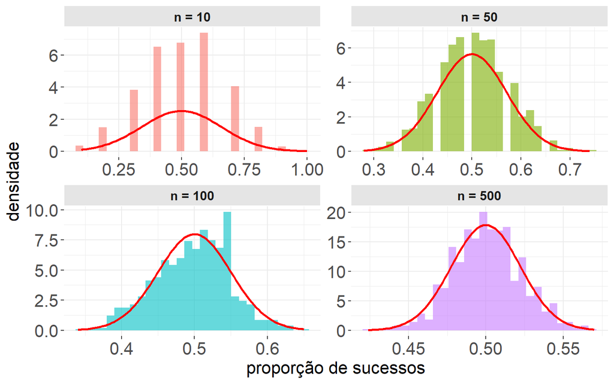

```r
# Proporção de sucesso na população
p = 0.5

# Tamanhos das amostras
n_amostras <- c(10, 50, 100, 500)

# Número de simulações
n_simulacoes <- 1000

# Simulação da proporção
simula_proporcoes <- function(n, p, n_simulacoes) {
  proporcoes <- replicate(n_simulacoes, {
    amostra <- rbinom(n, 1, p)  # n lançamentos
    mean(amostra)  # Proporção de sucessos
  })
  data.frame(tamanho = n, proporcao = proporcoes)
}

# Gerar os dados para todos os tamanhos de amostra
dados_proporcao <- map_dfr(n_amostras, ~ simula_proporcoes(.x, p, n_simulacoes))

# Função para obter o desvio padrão teórico da distribuição amostral
calcula_sd_teorico <- function(n, p) {
  sqrt(p * (1 - p) / n)
}

# Personalizar os rótulos do facet_wrap
n_labels <- c("n = 10", "n = 50", "n = 100", "n = 500")

# Visualização com ggplot
ggplot(dados_proporcao, aes(x = proporcao, fill = as.factor(tamanho))) +
  geom_histogram(aes(y = ..density..), bins = 30, alpha = 0.6, position = "identity") +
  facet_wrap(~ tamanho, scales = "free", labeller = as_labeller(setNames(n_labels, n_amostras))) +
  stat_function(fun = dnorm, args = list(mean = p, sd = calcula_sd_teorico(10, p)),
                color = "red", size = 1, data = subset(dados_proporcao, tamanho == 10)) +
  stat_function(fun = dnorm, args = list(mean = p, sd = calcula_sd_teorico(50, p)),
                color = "red", size = 1, data = subset(dados_proporcao, tamanho == 50)) +
  stat_function(fun = dnorm, args = list(mean = p, sd = calcula_sd_teorico(100, p)),
                color = "red", size = 1, data = subset(dados_proporcao, tamanho == 100)) +
  stat_function(fun = dnorm, args = list(mean = p, sd = calcula_sd_teorico(500, p)),
                color = "red", size = 1, data = subset(dados_proporcao, tamanho == 500)) +
  labs(x = "proporção de sucessos", y = "densidade") +
  theme_bw() +
  theme(axis.text.x = element_text(size = 16),
        axis.title.x = element_text(size = 16),
        axis.text.y = element_text(size = 16),
        axis.title.y = element_text(size = 16),
        panel.border = element_blank(),
        legend.position = "none",
        legend.text = element_text(size = 12),
        strip.background = element_rect(fill="gray90",colour = "white"),
        strip.text = element_text(face = "bold", size = 12))
```

### Teorema para a Distribuição da Variância Amostral

Seja $\sigma^2$ a variância populacional. A variância amostral $S^2$ segue uma distribuição relacionada à distribuição qui-quadrado com $n - 1$ graus de liberdade:

$$\frac{(n - 1)S^2}{\sigma^2} \sim \chi^2(n - 1)$$

Essa relação mostra que a variância amostral $S^2$ está distribuída de acordo com uma qui-quadrado normalizada com $n - 1$ graus de liberdade.

Vamos analisar a variância amostral para uma população com altura média de 170 cm e desvio padrão populacional de 10 cm. Faremos simulações para diferentes tamanhos de amostra e compararemos as distribuições amostrais da variância amostral $S^2$ com a variância populacional $\sigma^2$.

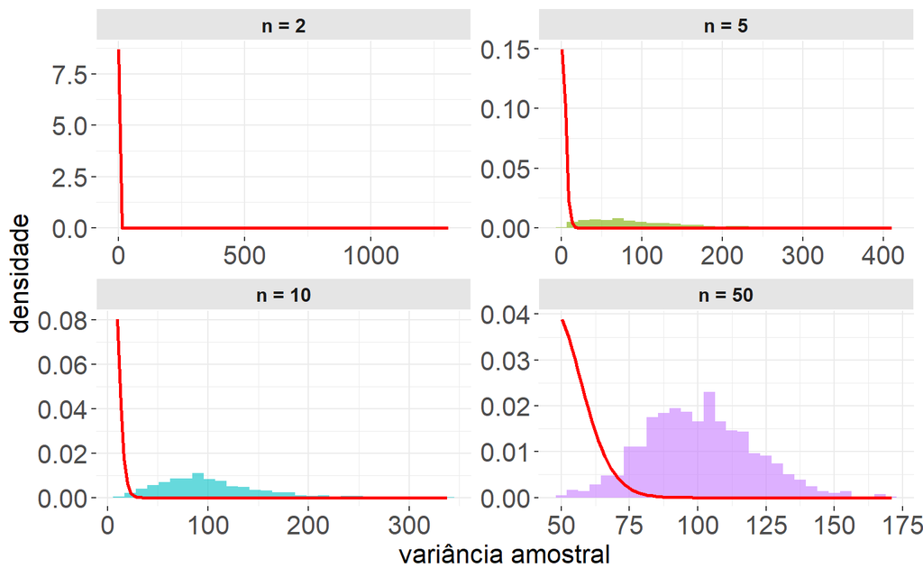

```r
# Parâmetros
mu <- 170  # Média populacional
sigma <- 10  # Desvio padrão populacional
sigma2 <- sigma^2  # Variância populacional
n_amostras <- c(2, 5, 10, 50)  # Tamanhos das amostras
n_simulacoes <- 1000  # Número de simulações

# Função para simular variâncias amostrais
simula_variancia <- function(n, mu, sigma, n_simulacoes) {
  variancias <- replicate(n_simulacoes, {
    amostra <- rnorm(n, mean = mu, sd = sigma)
    var(amostra)
  })
  data.frame(tamanho = n, variancia = variancias)
}

# Gerar os dados para todos os tamanhos de amostra
dados_variancia <- map_dfr(n_amostras, ~ simula_variancia(.x, mu, sigma, n_simulacoes))

# Função para calcular o desvio padrão teórico da distribuição amostral da variância
calcula_sd_variancia <- function(n, sigma) {
  sqrt(2 * sigma^4 / (n - 1))
}

# Rótulos para o facet_wrap
n_labels <- c("n = 2", "n = 5", "n = 10", "n = 50")

# Visualização com ggplot
ggplot(dados_variancia, aes(x = variancia, fill = as.factor(tamanho))) +
  geom_histogram(aes(y = ..density..), bins = 30, alpha = 0.6, position = "identity") +
  facet_wrap(~ tamanho, scales = "free", labeller = as_labeller(setNames(n_labels, n_amostras))) +
  stat_function(fun = dchisq, args = list(df=1),
                color = "red", size = 1, data = subset(dados_variancia, tamanho == 2)) +
  stat_function(fun = dchisq, args = list(df=4),
                color = "red", size = 1, data = subset(dados_variancia, tamanho == 5)) +
  stat_function(fun = dchisq, args = list(df=9),
                color = "red", size = 1, data = subset(dados_variancia, tamanho == 10)) +
  stat_function(fun = dchisq, args = list(df=49),
                color = "red", size = 1, data = subset(dados_variancia, tamanho == 50)) +
  labs(x = "variância amostral", y = "densidade") +
  theme_bw() +
  theme(axis.text.x = element_text(size = 16),
        axis.title.x = element_text(size = 16),
        axis.text.y = element_text(size = 16),
        axis.title.y = element_text(size = 16),
        panel.border = element_blank(),
        legend.position = "none",
        legend.text = element_text(size = 12),
        strip.background = element_rect(fill="gray90",colour = "white"),
        strip.text = element_text(face = "bold", size = 12))
```

> **Desafio:** Considere $X \sim Beta(\alpha,\beta)$ e $X_1,X_2,\ldots, X_n$ uma amostra iid dessa população. Retire 500 amostras de tamanho $n=100$ e obtenha a mediana de cada amostra. Faça uma representação gráfica para visualizar a distribuição amostral da mediana, traçando uma reta vertical com o valor da mediana teórica.